# Group 02 - Skin Cancer

Leonie Thomas, Isabel Potthof, Elif Tosun and Marlene Khin

24.07.2019

# 1.We need to load all needed packages:

# 3. Loading the dataset:

# **Part 1: Data Cleanup**

## **1.1 Extracting and splitting our data**

The mutation data is different from the other matrixes, so we define a new matrix only containing the mutation data

defining the samples so we can extract only our cancer type of interest

```r
sample_case = c("Skin Cancer")
```

We look at the annotation matrix an search only for the Primary diseases which match the previous defined sample case (Skin cancer)

```r
samples = data$annotation$DepMap_ID[which(data$annotation$Primary.Disease == sample_case)]
```

extracting only the celllines with skin cancer as the primary disease from our matrices (dt_new) and save the new matrices in a new large list (processed_data)

Losing the mutations which are not deleterious meaning not interesting to us

```r
allDepMap_mutation_SkinCancer = lapply(1:34, function(a) {allDepMap_mutation_SkinCancer[[a]][which(allDepMap_mutation_SkinCancer[[a]][,"isDeleterious"]== TRUE), ]})
```

losing all the genes which are not in every data frame

```r
 a <- unique(c(rownames(processed_data[[1]]),rownames(processed_data[[2]]),rownames(processed_data[[3]]),rownames(processed_data[[4]])))

i <- 1
out <- vector("character", length(seq_along(1:16970)))
for (x in seq_along(a)) {
  if(a[x] %in% rownames(processed_data$expression) & a[x] %in% rownames(processed_data$copynumber) & a[x] %in% rownames(processed_data$kd.ceres) & a[x] %in% rownames(processed_data$kd.prob))
  {out[i] <- a[x]
  i <- i+1
  }
}

processed_data2 <- processed_data

processed_data2 <- lapply(processed_data, function(a) {
  a <- a[which(rownames(a) %in% out),]
  return(a)
})
processed_data2$annotation <- processed_data$annotation
processed_data <- processed_data2
rm(processed_data2)
```

# **Part 2: Data vizualisation**

## **2.1 Preparing our data for plotting**

Creating new data for plotting out of our data of interest

## **2.2 creating a heatmap with the kd.ceres values**

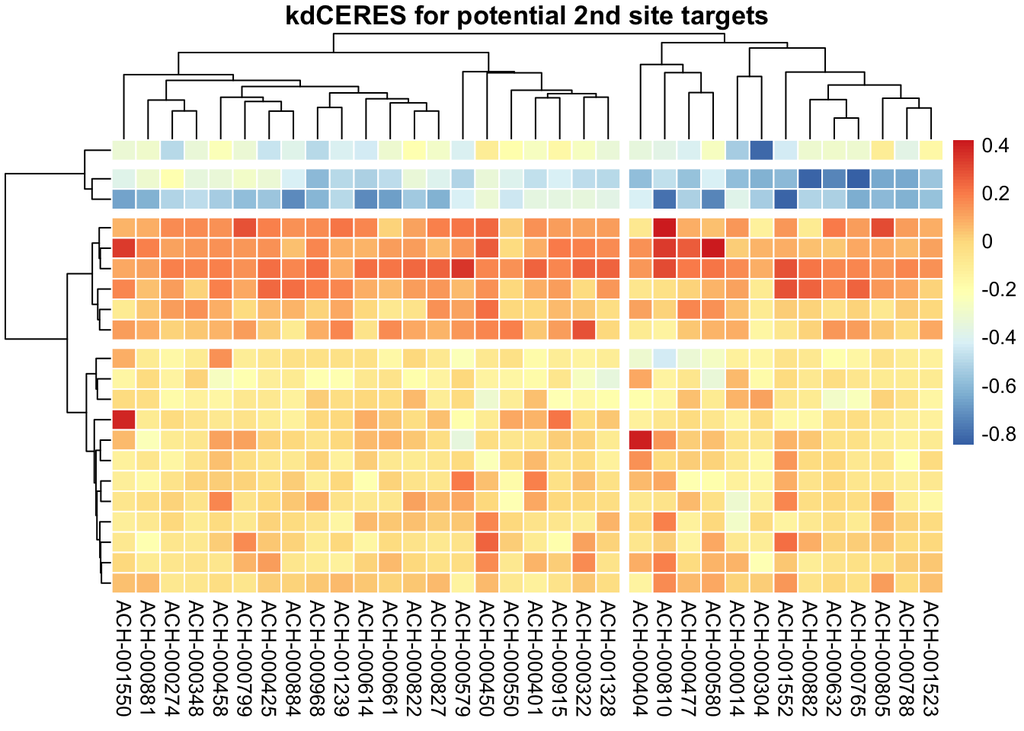

```r
pheatmap(as.matrix(processed_data$kd.ceres[25:45, 1:34]), clustering_method = "ward.D2",border_color = "white", fontsize = 10,
         main = paste0("kdCERES for potential 2nd site targets"),
         show_rownames = F, show_colnames = T,
         cutree_rows = 4,
         cutree_cols = 2,
         fontsize_row=10)
```

***  
> + the knockout of the different genes influences the cells in different ways

## **2.4 Creating boxplots of expression and mutation data to get an overview of our data**

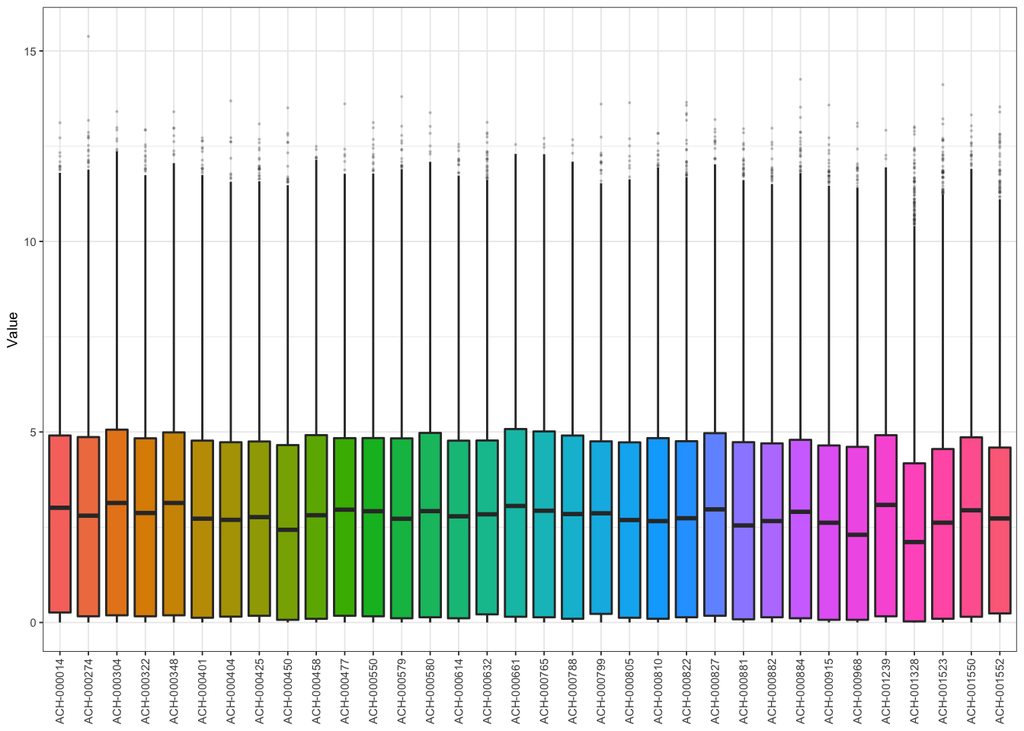

```r
ggplot(data = finalPlottingData$expression, aes(x=Sample, y=Value)) +
  geom_boxplot(aes(fill = Sample), outlier.size = 0.1, outlier.alpha = 0.2) +
  theme_bw(base_size = 7) +
  theme(legend.position= "none",
        legend.direction="horizontal",
        plot.title = element_text(hjust = 0.5),
        axis.text.x = element_text(angle = 90, vjust = 0.5, hjust=1),
        legend.title= element_blank(),
        axis.title.x = element_blank(),
        strip.text.y = element_text(angle = 90))
```

*> there are outliers in every cellline which can be examined*

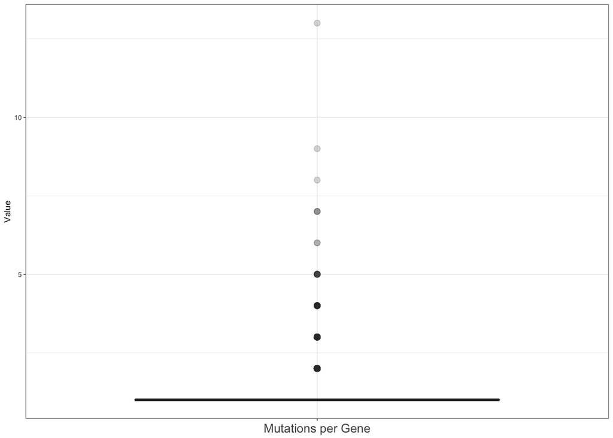

```r
geneCounts <- cbind(geneCounts, "Mutations per Gene")

ggplot(data = geneCounts, aes(x="Mutations per Gene", y=Value)) +
  geom_boxplot(aes(fill = "Mutations per Gene"), outlier.size = 2, outlier.alpha = 0.2) +
  theme_bw(base_size = 7) +
  theme(legend.position= "none",
        legend.direction="horizontal",
        plot.title = element_text(hjust = 0.5),
        axis.text.x = element_text(angle = 0, vjust = 0.5, hjust= 0.5, size = 10),
        legend.title= element_blank(),
        axis.title.x = element_blank(),
        strip.text.y = element_text(angle = 90))
```

*> only a few genes are often mutated, so it should be good to define driver mutations*

## **2.5 Extract the data for the top 40**

Extract the data for epression and ceres

putting the names of the matrixes in one allDep_mutation

## **2.6 Plotting only the top 10 genes -> driver mutations**

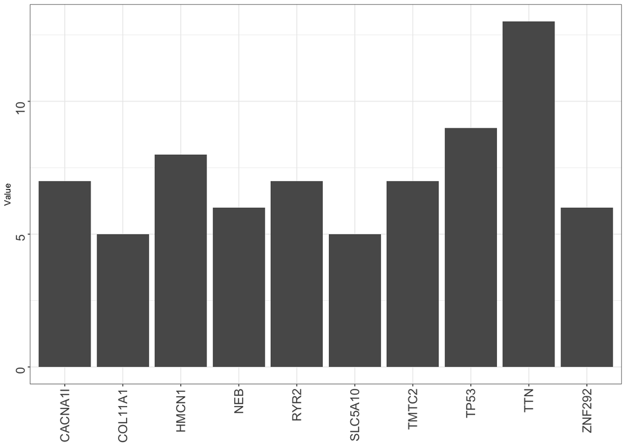

```r
plotData <- sortedGenCounts[1:10, ,drop = FALSE]

plotData$Gene <- rownames(plotData)

ggplot(data = plotData) +
  (geom_bar(mapping = aes(x = Gene, y = Value), stat = "identity")) +
  theme_bw(base_size = 7) +
  theme(legend.position= "none",
        legend.direction="horizontal",
        plot.title = element_text(hjust = 0.5),
        axis.text.x = element_text(angle = 90, vjust = 0.5, hjust=1, size = 10),
        axis.text.y = element_text(angle = 90, vjust = 0.5, hjust=1, size = 10),
        legend.title= element_blank(),
        axis.title.x = element_blank(),
        strip.text.y = element_text(angle = 90))
```